# Exercise 12

Logan Arnold

11/17/2017

## Problem 1

### Describe data

We will be working with the data set “chickwts.txt”, which has columns of chick weight and feed type. Let’s start by reading in the data:

```r
data1 <- read.table(file = "chickwts.txt", header = TRUE, sep = ",")
attach(data1)
print(data1)
```

```
##    weight      feed
## 1     179 horsebean
## 2     160 horsebean
## 3     136 horsebean
## 4     227 horsebean
## 5     217 horsebean
## 6     168 horsebean
## 7     108 horsebean
## 8     124 horsebean
## 9     143 horsebean
## 10    140 horsebean
## 11    309   linseed
## 12    229   linseed
## 13    181   linseed
## 14    141   linseed
```

[output cut: 57 more lines]

### Including Plots

Let’s plot the data

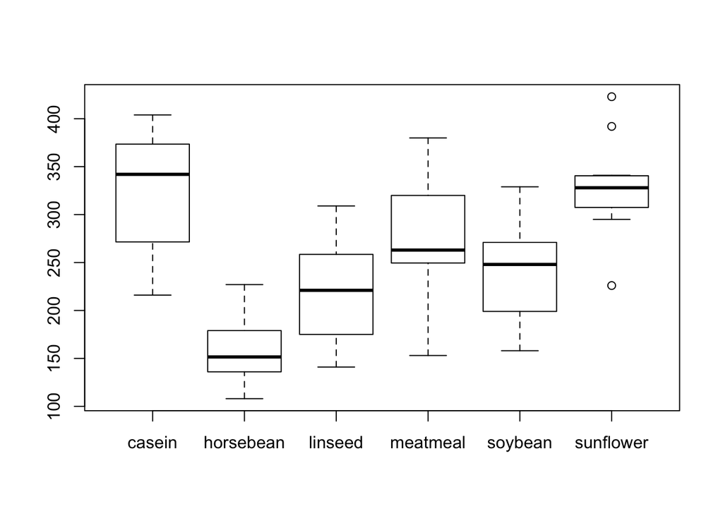

```r
plot(feed, weight)
```

### Statistics

Now let’s consider a hypothesis our data. Specifically, we will look at the feed types soybean vs. sunflower. Are the chick weight statistically significantly different for these two types of food?

We have a null hypothesis:

*No, there is no difference in weight.*

And an alternative hypothesis:

*Yes, there is a difference in weight.*

In order to test this hypothesis, we must subset the data so that it only contains the feed type of interest. Then, we must create a categorical variable to represent feed type. We will set *soybean* as 0 and *sunflower* as 1.

```r
n <- dim(data1)[1]
j <- 1
k <- 1
soybeanWeight <- NULL
sunflowerWeight <- NULL

for (i in 1:n) {
  if (data1[i,2] == "soybean") {
    soybeanWeight[j] = data1[i,1]
    j = j+1
}
  if (data1[i,2] == "sunflower") {
    sunflowerWeight[k] = data1[i,1]
    k = k+1
  }
}

Weight <- c(soybeanWeight, sunflowerWeight)
feedSoy <- rep(0, length(soybeanWeight))
feedSunflower <- rep(1, length(sunflowerWeight))
Feed <- c(feedSoy, feedSunflower)

data2 <- data.frame(Weight, Feed)
```

### Testing the hypotheses

We will be using a liklihood ratio test to evaluate our hypotheses. To do this, we will use a negative log likelihood function, then compare the results using a chi-squared test.

First, let’s create our likelihood functions, first for the null hypothesis then for the alternative hypothesis. After the functions have been created, let’s fit our model.

```r
nllike=function(p,x,y){
  B0=p[1]
  B1=p[2]
  sigma=exp(p[3])

  expected=B0+B1*x

  nll=-sum(dnorm(x=y, mean =expected, sd=sigma, log=TRUE))
  return(nll)
}

nllikeNull=function(p,x,y){
  B0=p[1]
  sigma=exp(p[2])

  expected=B0

  nll=-sum(dnorm(x=y, mean =expected, sd=sigma, log=TRUE))
  return(nll)
}

fitNull=optim(par=c(250,10), fn=nllikeNull,
                   y=data2[,1])
fitLinear=optim(par=c(250,10,10), fn=nllike,
                     x=data2[,2], y=data2[,1])
```

### Evaluating the Models

The final step is to evaluate our models using the chi-squared test. The test statistic is 2 times the difference in the NLL obtained from our optimization step.

```r
pval = pchisq(q=(2*(fitNull$value-fitLinear$value)), df=1,
             lower.tail = FALSE)
```